# The other Marshmallow Task!

Dr. Gordon Wright

## Today’s Experiment: The Marshmallow Challenge

**Build the tallest free-standing structure using:**

- 20 sticks of spaghetti

- 1 meter of tape

- 1 meter of string

- 1 marshmallow (must be on top!)

- At least one team-member swaps at start of each block

## Pre-challenge Predictions

Think psychologically!

Think theoretically!

Any ideas? Any hypotheses?

## Group Dynamics

- How do strangers form working relationships?
- Social facilitation vs. social loafing
- In-group formation
- Status and power dynamics

## Cognitive Biases

- Functional fixedness (seeing objects only for their intended use)
- Planning fallacy (underestimating time needed)
- Overconfidence effect

## Decision-Making Under Pressure

- Impact of stress on cognitive performance
- Satisficing vs. optimizing strategies

## Research Methods Preview (1): Variables

- **Independent variables:** Group composition
- **Dependent variables:** Tower height, completion
- **Control variables:** Same materials, instructions

## Research Methods Preview (2): Observation Methods

- Structured observation
- Behavioral coding
- Process analysis

## Behavioural Coding Techniques

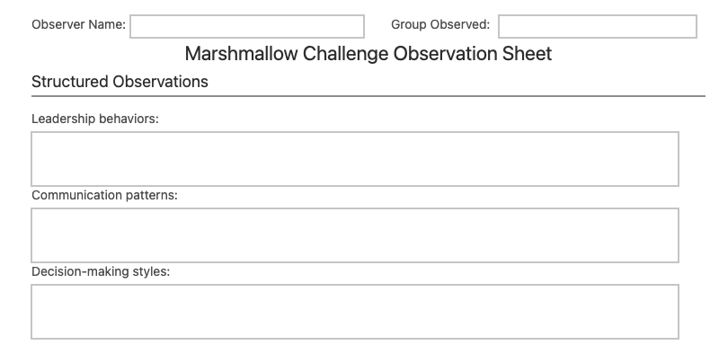

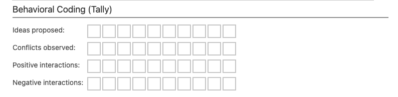

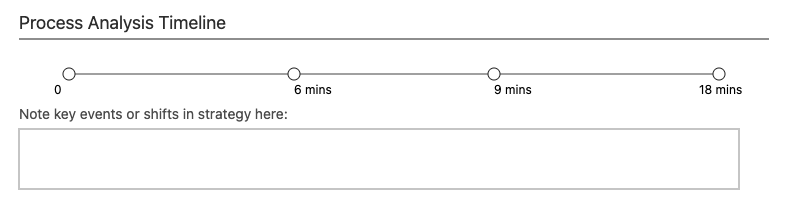

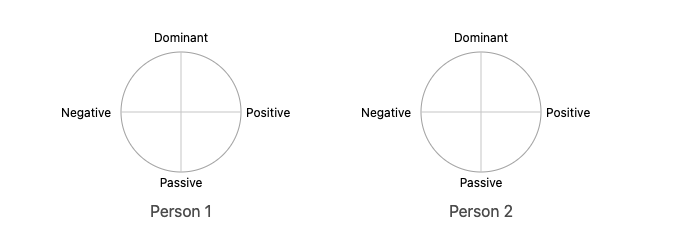

## Research Methods Preview (3): Data Analysis

- Quantitative (height measurements)
- Qualitative (group dynamics)

## Observer Roles (1): Communication and Decision-making

- **Communication patterns**
  - Who speaks? How often? Who listens?
  - Verbal vs. non-verbal communication
- **Decision-making processes**
  - How are ideas generated and evaluated?
  - Is there evidence of groupthink?

## Observer Roles (2): Leadership Emergence

- **Leadership emergence**
  - Formal vs. informal leadership
  - Leadership styles (directive, participative)

## Observer Roles (3): Conflict Resolution

- **Conflict resolution**
  - How are disagreements handled?
  - Constructive vs. destructive conflict

## Now, Let’s Begin!

**18:00 minutes on the clock…**

## Block 1

## Block 2

## Block 3

## Post-Challenge Analysis

### Tuckman’s Stages of Group Development

- **Forming**: Orientation, testing boundaries
- **Storming**: Conflict, resistance to task demands
- **Norming**: Development of group cohesion
- **Performing**: Functional role relatedness
- **Adjourning**: Completion and disengagement (Tuckman, 1965)

## Cognitive Biases in Action

**Did we see these? We do usually!**

- **Planning fallacy**: Groups overestimated what they could accomplish
- **Functional fixedness**: Limited vision of how materials could be used
- **Overconfidence bias**: Initial certainty vs. final outcomes
- **Sunk cost fallacy**: Continuing with failing approaches

## Stress and Creativity

- Yerkes-Dodson Law: Optimal arousal (Yerkes & Dodson, 1908)
- Time pressure effects on divergent thinking
- Impact of evaluation apprehension (Amabile et al., 2002)
- Stress responses: Fight, flight, or freeze in team contexts

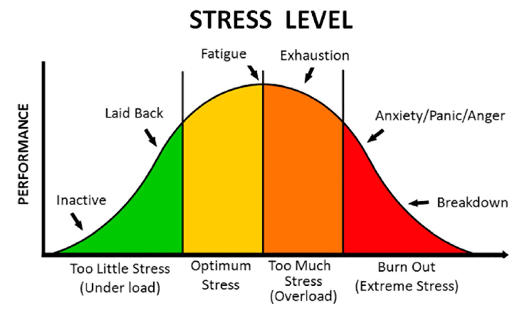

## Psychology Careers Connection

- Organizational Psychology
- Clinical Psychology
- Developmental Psychology
- Forensic Psychology
- Team effectiveness assessment
- Leadership development
- Workplace interventions
- Change management
- Group therapy dynamics
- Behavioral observation
- Interpersonal functioning
- Stress responses
- Age differences in approach
- Learning through play
- Concrete vs. abstract thinking
- Social development
- Behavioural analysis and profiling
- Witness reliability assessment
- Decision-making under pressure
- Group dynamics in legal contexts

## The Research Behind the Challenge

- **Collaborative problem-solving**:
- Coordination costs vs. diversity benefits
- Psychological safety (Edmondson, 1999)
- **Creative thinking principles**:
- Divergent vs. convergent thinking phases
- Prototype testing and iteration (Brown, 2009)
- **Mindset research**:
- Fixed vs. growth mindset (Dweck, 2006)
- Impact on persistence and approach to failure

## The Kindergarten Advantage

**Why children often outperform business students:**

1. Rapid prototyping - testing early and often
2. No status management or impression concerns
3. Learning through play - less fear of failure
4. Less fixated on “one right way” to solve problems
5. Natural collaboration without hierarchy

## Follow-up Activity: Design Your Experiment

**In groups, design a variation of this challenge to test:**

- How would you modify the challenge to test a specific psychological variable?
- What would you measure and how?
- What hypotheses would you propose?
- What interventions might improve performance?

## Thank you

Any questions?